# Financial Data Analytics in Python

# Complex data structures

## NumPy

NumPy is a well-known library utilized for storing numerical arrays and carrying out computations on them. This not only allows for more concise code but also enhances its efficiency as most NumPy functions are designed in C for faster processing.

See:

- https://numpy.org/doc/1.24/
- https://numpy.org/doc/1.24/user/absolute_beginners.html

Arrays are the central data structure in NumPy, and they are used to store homogeneous data. A NumPy array is similar to a list in Python, but it is more efficient in handling large amounts of data. In addition, NumPy arrays are highly optimized for numerical computations and support a wide range of mathematical operations.

To use NumPy in Python, you need to import the NumPy library using the import statement. Here is an example of importing NumPy and creating a simple array:

```python
import numpy as np

# create a one-dimensional array
arr = np.array([1, 2, 3, 4, 5])
print(arr)
```

```
[1 2 3 4 5]
```

NumPy provides several functions to create arrays of different shapes and sizes. For example, you can create a two-dimensional array using the `np.array()` function with a list of lists:

```python
# create a two-dimensional array
arr2d = np.array([[1, 2, 3], [4, 5, 6]])
print(arr2d)
```

```
[[1 2 3]
 [4 5 6]]
```

You can also create arrays of zeros or ones using the `np.zeros()` and `np.ones()` functions, respectively:

```python
# create an array of zeros
zeros_arr = np.zeros((2, 3))
print(zeros_arr)

# create an array of ones
ones_arr = np.ones((2, 3))
print(ones_arr)
```

```
[[0. 0. 0.]
 [0. 0. 0.]]
[[1. 1. 1.]
 [1. 1. 1.]]
```

NumPy provides many built-in functions for mathematical operations, such as `np.sum()`, `np.mean()`, `np.std()`, and `np.dot()`. These functions can be used to perform mathematical operations on arrays:

```python
# sum of all elements in an array
arr_sum = np.sum(arr)
print(arr_sum)

# mean of all elements in an array
arr_mean = np.mean(arr)
print(arr_mean)

# standard deviation of all elements in an array
arr_std = np.std(arr)
print(arr_std)

# dot product of two arrays
arr1 = np.array([1, 2, 3])
arr2 = np.array([4, 5, 6])
arr_dot = np.dot(arr1, arr2)
print(arr_dot)
```

```
15
3.0
1.4142135623730951
32
```

## Pandas

Python pandas is an open-source library used for data manipulation and analysis. It provides highly efficient and flexible data structures for handling various data types, including tabular, time-series, and matrix data. Pandas offers two primary data structures, Series and DataFrame, that enable data cleaning, preprocessing, and analysis in a quick and intuitive manner. It also provides functions for reading and writing data from various file formats, such as CSV, Excel, SQL databases, and more. Python pandas is widely used in data science, machine learning, and financial analysis due to its robust capabilities for handling and analyzing large datasets.

See:

- https://pandas.pydata.org/docs/
- https://pandas.pydata.org/docs/getting_started/index.html

Data frames are the primary data structure in Pandas, and they are used to store two-dimensional data. A data frame is similar to a spreadsheet, where each column can have a different data type. Pandas data frames can be created from a variety of sources, including CSV files, Excel files, SQL databases, and more.

To use Pandas in Python, you need to import the Pandas library using the import statement. Here is an example of importing Pandas and creating a simple data frame:

```python
import pandas as pd

# Create data using a dictionary
data = {'Name': ['John', 'Mary', 'Peter', 'Anna'],
        'Age': [25, 30, 28, 35],
        'City': ['New York', 'Paris', 'London', 'Sydney']}

# Convert the dictionary into a DataFrame
df = pd.DataFrame(data)
```

```python
# You can print a data frame, however, ...
print(df)
# ... display() makes it look nicer in notebooks(!)
display(df)
```

```
    Name  Age      City
0   John   25  New York
1   Mary   30     Paris
2  Peter   28    London
3   Anna   35    Sydney
```

|  | Name | Age | City |
| --- | --- | --- | --- |
| 0 | John | 25 | New York |
| 1 | Mary | 30 | Paris |
| 2 | Peter | 28 | London |
| 3 | Anna | 35 | Sydney |

Pandas provides several functions to manipulate data frames, such as selecting, filtering, and sorting data. For example, you can select specific columns from a data frame using the column name:

```python
# select specific columns
name_age = df[['Name', 'Age']]
display(name_age)
```

|  | Name | Age |
| --- | --- | --- |
| 0 | John | 25 |
| 1 | Mary | 30 |
| 2 | Peter | 28 |
| 3 | Anna | 35 |

You can also filter data based on specific criteria using Boolean indexing:

```python
# filter data based on criteria
filtered_df = df[df['Age'] > 28]
display(filtered_df)
```

|  | Name | Age | City |
| --- | --- | --- | --- |
| 1 | Mary | 30 | Paris |
| 3 | Anna | 35 | Sydney |

`describe()`

Produces summary statistics

```python
# summarize data
summary = df.describe()
display(summary)
```

|  | Age |
| --- | --- |
| count | 4.000000 |
| mean | 29.500000 |
| std | 4.203173 |
| min | 25.000000 |
| 25% | 27.250000 |
| 50% | 29.000000 |
| 75% | 31.250000 |
| max | 35.000000 |

`groupby()`

Aggregates data

```python
# group data by a column
grouped_df = df.groupby('City')
display(grouped_df["Age"].mean())
```

```
City
London      28.0
New York    25.0
Paris       30.0
Sydney      35.0
Name: Age, dtype: float64
```

# Plotting

## Matplotlib

Matplotlib is a data visualization library in Python that provides a comprehensive set of tools for creating static, animated, and interactive visualizations in Python. It enables users to generate high-quality 2D and 3D plots, histograms, scatterplots, bar charts, and other visualizations. Matplotlib is highly customizable, with extensive support for customizing colors, fonts, line styles, and markers, and also allows the creation of complex plots and subplots with minimal effort. The library provides both low-level and high-level APIs, which enable users to build simple or complex visualizations based on their needs. Matplotlib is widely used in scientific computing, data analysis, machine learning, and other fields that require data visualization for communication and analysis.

See:

- https://matplotlib.org/stable/index.html
- https://matplotlib.org/stable/tutorials/introductory/quick_start.html

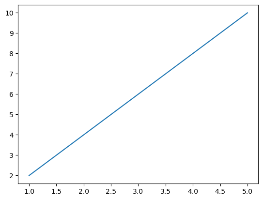

```python
import matplotlib.pyplot as plt

# create a simple line plot
x = [1, 2, 3, 4, 5]
y = [2, 4, 6, 8, 10]
plt.plot(x, y)
plt.show()
```

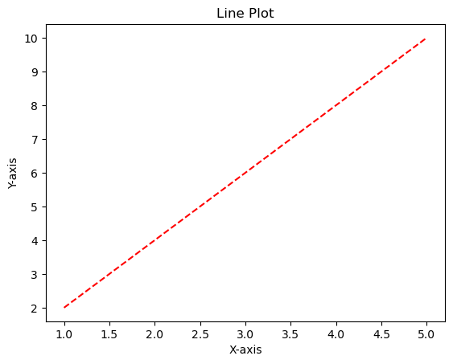

```python
# customize the line plot
plt.plot(x, y, color='red', linestyle='dashed')
plt.xlabel('X-axis')
plt.ylabel('Y-axis')
plt.title('Line Plot')
plt.show()
```

Matplotlib is a very versatile tool that can be easily customized. See:

- https://matplotlib.org/stable/api/_as_gen/matplotlib.pyplot.subplots.html
- https://matplotlib.org/stable/gallery/index

```python
# generate some sample data
x = np.arange(0, 10, 0.1)
y1 = np.sin(x)
y2 = np.cos(x)

# create the figure and subplots
fig, ax1 = plt.subplots()

# create a second y-axis
ax2 = ax1.twinx()

# plot the data on the first y-axis
ax1.plot(x, y1, color='blue')
ax1.set_xlabel('x')
ax1.set_ylabel('sin(x)', color='blue')
ax1.tick_params(axis='y', labelcolor='blue')

# plot the data on the second y-axis
ax2.plot(x, y2, color='red')
ax2.set_ylabel('cos(x)', color='red')
ax2.tick_params(axis='y', labelcolor='red')

# set the title of the plot
plt.title('Two y-axes example')

# Prevent the automatic display (I only need this for my slides)
plt.close(fig)
```

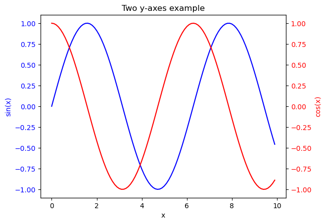

```python
# Lets display the plot on a different slide
display(fig)
```

## Seaborn

Seaborn is a Python data visualization library based on Matplotlib that provides a higher-level interface for creating informative and attractive statistical graphics. Seaborn simplifies the process of generating complex plots, such as heatmaps, time series, and categorical plots, by providing built-in functions that allow for easy customization of visual elements, color palettes, and themes. Seaborn also includes statistical functions that help in data exploration and modeling, such as regression plots, distribution plots, and categorical plots. Seaborn's API is designed to work seamlessly with Pandas data structures, making it an excellent tool for data analysis and data-driven storytelling. Seaborn is commonly used in fields such as data science, machine learning, and social sciences, where data visualization plays a crucial role in data analysis and communication.

See:

- https://seaborn.pydata.org/tutorial.html

To use Seaborn in Python, you need to import the Seaborn library using the import statement. Here is an example of importing Seaborn and creating a simple line plot:

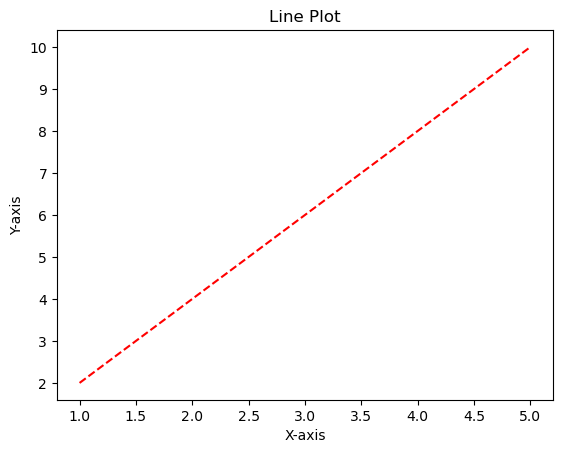

```python
import seaborn as sns

# Example data
x = [1, 2, 3, 4, 5]
y = [2, 4, 6, 8, 10]

# customize the line plot
sns.lineplot(x=x, y=y, color='red', linestyle='dashed')
plt.xlabel('X-axis')
plt.ylabel('Y-axis')
plt.title('Line Plot')
plt.show()
```

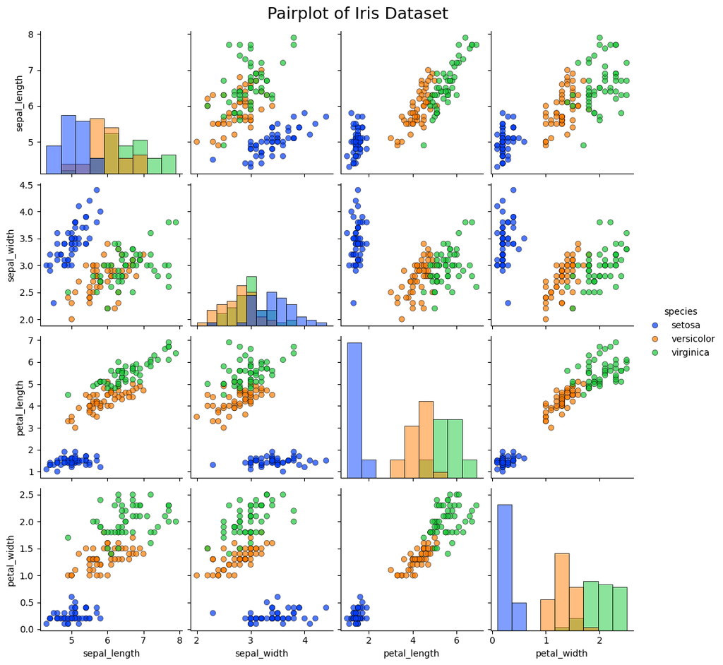

```python
# load the iris dataset
iris = sns.load_dataset("iris")

# create a pairplot with color-coded points based on species
fig = sns.pairplot(iris, hue="species", diag_kind="hist",
             diag_kws=dict(edgecolor="k", linewidth=0.5),
             plot_kws=dict(edgecolor="k", linewidth=0.5, alpha=0.7),
             palette="bright")

# add a title
plt.suptitle("Pairplot of Iris Dataset", y=1.02, fontsize=18)

# show the plot
plt.show()
```

```python
# This is how the data looks like
display(iris)
# This is just another Pandas data frame
print(type(iris))
```

|  | sepal_length | sepal_width | petal_length | petal_width | species |
| --- | --- | --- | --- | --- | --- |
| 0 | 5.1 | 3.5 | 1.4 | 0.2 | setosa |
| 1 | 4.9 | 3.0 | 1.4 | 0.2 | setosa |
| 2 | 4.7 | 3.2 | 1.3 | 0.2 | setosa |
| 3 | 4.6 | 3.1 | 1.5 | 0.2 | setosa |
| 4 | 5.0 | 3.6 | 1.4 | 0.2 | setosa |
| ... | ... | ... | ... | ... | ... |
| 145 | 6.7 | 3.0 | 5.2 | 2.3 | virginica |
| 146 | 6.3 | 2.5 | 5.0 | 1.9 | virginica |
| 147 | 6.5 | 3.0 | 5.2 | 2.0 | virginica |
| 148 | 6.2 | 3.4 | 5.4 | 2.3 | virginica |
| 149 | 5.9 | 3.0 | 5.1 | 1.8 | virginica |

150 rows × 5 columns

```
<class 'pandas.core.frame.DataFrame'>
```